# Trabalho ECDB - Grupo 4

# 15 **Seleção/Importância de genes**

Neste caso em estudo é calculada a importância das variáveis (genes) para cada modelo, através da função `varImp()`.

Existe uma consensualidade nos resultados de todos os modelos, com a exceção do Decision Tree. Em todos os outros modelos o gene [ENSG00000237424.1 (FOXD2-AS1)](https://www.ensembl.org/Homo_sapiens/Gene/Summary?db=core;g=ENSG00000237424;r=1:47432133-47434641;t=ENST00000445551) é o que apresenta maior importância, enquanto que, para a Decision Tree é o gene [ENSG00000278966.2](https://www.ensembl.org/Homo_sapiens/Gene/Summary?db=core;g=ENSG00000278966;r=1:32973553-32974463).

Uma vez que os resultados obtidos para a Decision Tree não foram de acordo com o esperado em comparação com os restantes modelos, decidiu-se que os resultados da seleção/importância de genes para o modelo Decision Tree não serão tão fiáveis como os restantes.

Assim sendo, os restantes modelos corroboram a informação científica disponível sobre este tipo de cancro ( cancro do tipo escamoso da cabeça e pescoço - HNSC) e o gene FOXD2-AS1 [2, 3].

Segundo a informação disponível o gene FOXD2-AS1 estará associado ao cancro HNSC ao atuar como uma proteína oncogénica, ao regular a proliferação e migração celular, além de suprimir a imunidade adaptativa ao modular o número e a função das células apresentadoras de antigénio (monócitos, linffócitos, mastócitos, células dendríticas, etc.) [2, 3].

O gene FOXD2-AS1 é ainda um marcador tumoral em pacientes com este tipo de cancro, tendo vindo a ser desenvolvidas novas terapias que levem à inibição deste gene [4].

## SVM

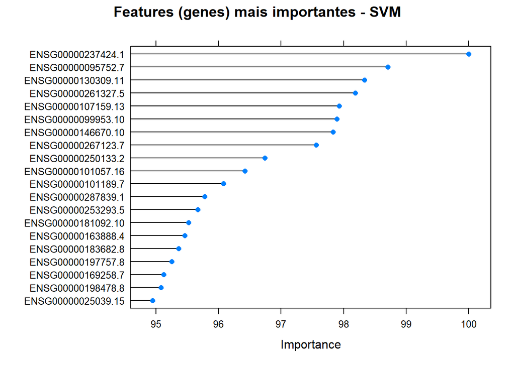

```r
importance_svm = varImp(svm_model)
plot(importance_svm, top=20, main='Features (genes) mais importantes - SVM')
```

## Decision Tree

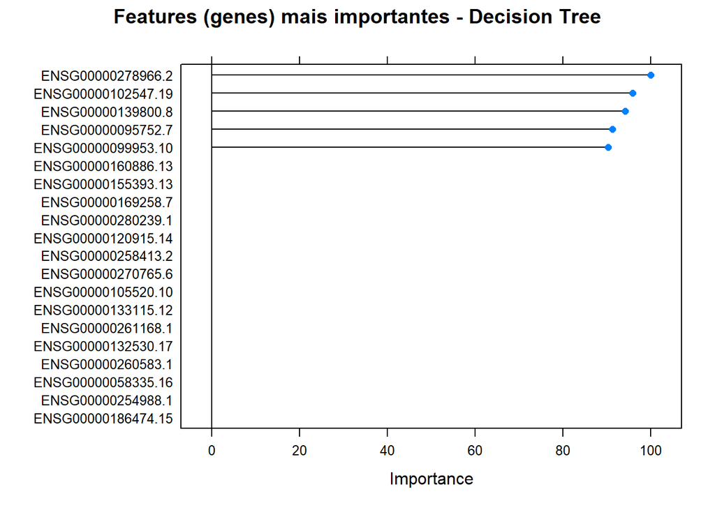

```r
importance_tree= varImp(decision_tree_model)
plot(importance_tree, top=20, main='Features (genes) mais importantes - Decision Tree')
```

## Multilayer Perceptron

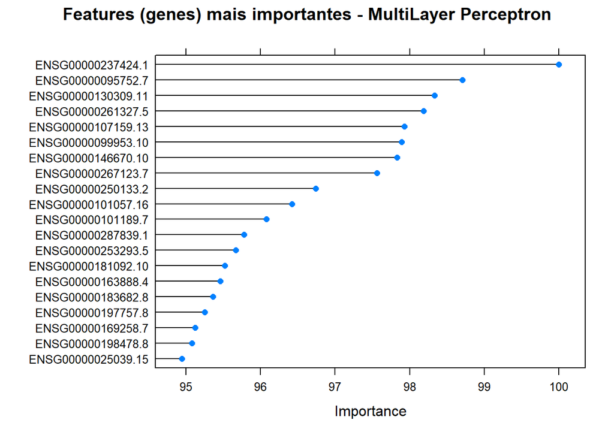

```r
importance_mlp = varImp(mlp_model_tuned)
plot(importance_mlp, top=20, main='Features (genes) mais importantes - MultiLayer Perceptron')
```

## KNN

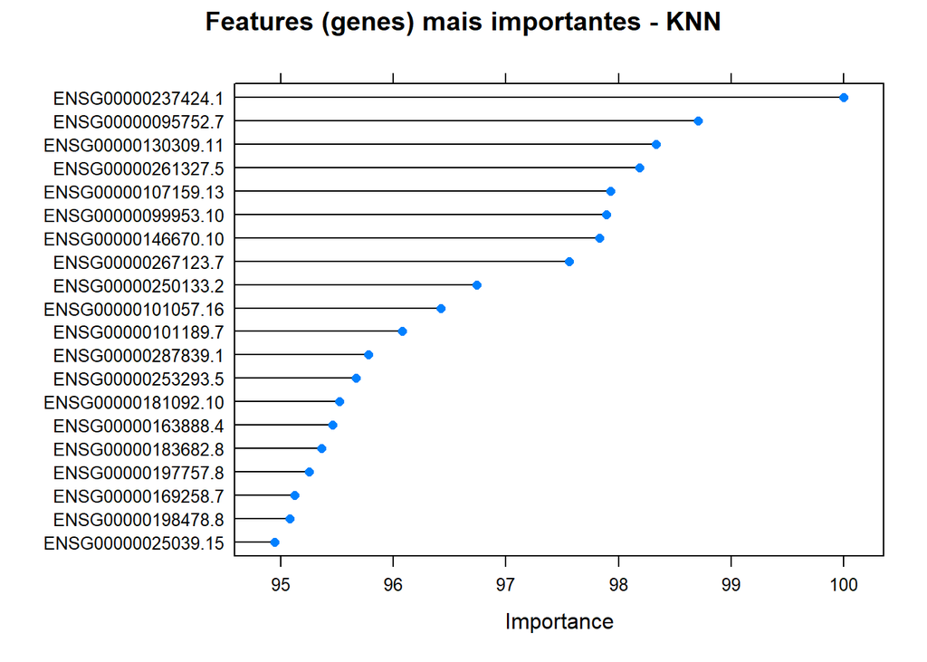

```r
importance_knn = varImp(knn_model)
plot(importance_knn, top=20, main='Features (genes) mais importantes - KNN')
```

## Naive Bayes

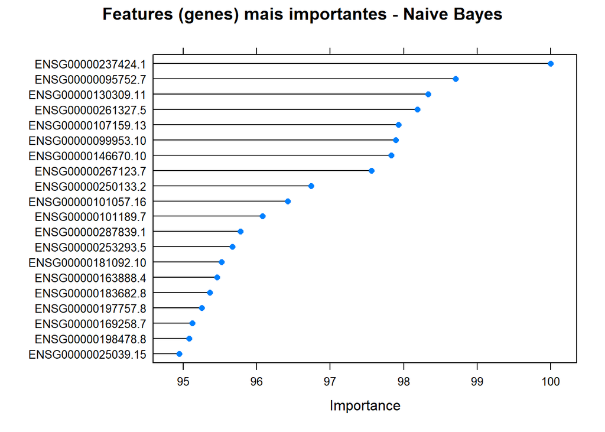

```r
importance_nb = varImp(nb_model)
plot(importance_nb, top=20, main='Features (genes) mais importantes - Naive Bayes')
```

# 16 **Conclusão**

Em suma, a partir do dataset inicialmente atribuido TCGA-HNSC foi possível analisar com sucesso quais são os genes diferencialmente expressos neste tipo de cancro, identificando também as suas principais funções através de uma análise de enriquecimento.

Para além disto, conseguimos ainda realizar com sucesso uma análise preditiva do tipo de tecido (normal ou tumoral) a partir de um conjunto de genes diferencialmente expressos. Neste caso, o modelo com maior sucesso foi o modelo de *Naive Bayes,* tendo conseguido prever corretamente todas as amostras em teste.

A partir da construção destes mesmos modelos, pudemos ainda destacar o gene FOXD2-AS1, como sendo um dos principais genes associados a este tipo de cancro.

# 17 **Referências**

[1] Pérez Sayáns M, Chamorro Petronacci CM, Lorenzo Pouso AI, Padín Iruegas E, Blanco Carrión A, Suárez Peñaranda JM, García García A. Comprehensive Genomic Review of TCGA Head and Neck Squamous Cell Carcinomas (HNSCC). J Clin Med. 2019 Nov 7;8(11):1896. doi: 10.3390/jcm8111896. PMID: 31703248; PMCID: PMC6912350.

[2] Zhang L, Bo H, Chen T, Li Q, Huan Y, Zhang S. *FOXD2-AS1* promotes migration and invasion of head and neck squamous cell carcinoma and predicts poor prognosis. Future Oncol. 2020 Oct;16(28):2209-2218. doi: 10.2217/fon-2020-0410. Epub 2020 Aug 7. PMID: 32762453.

[3] Liu Z, Zhou W, Lin C, Wang X, Zhang X, Zhang Y, Yang R, Chen W, Cao W. Dysregulation of FOXD2-AS1 promotes cell proliferation and migration and predicts poor prognosis in oral squamous cell carcinoma: a study based on TCGA data. Aging (Albany NY). 2020 Dec 9;13(2):2379-2396. doi: 10.18632/aging.202268. Epub 2020 Dec 9. PMID: 33318296; PMCID: PMC7880351.

[4] Zhou G, Huang Z, Meng Y, Jin T, Liang Y, Zhang B. Upregulation of long non-coding RNA FOXD2-AS1 promotes progression and predicts poor prognosis in tongue squamous cell carcinoma. J Oral Pathol Med. 2020 Nov;49(10):1011-1018. doi: 10.1111/jop.13074. Epub 2020 Jun 25. PMID: 32531865.